# Project 3: Exploring album sales and sentiment of lyrics from Beyoncé and Taylor Swift

Yunyi Ru

2024-10-20

# Set Up

```r
library("here")
library("tidyverse")
```

```r
library('tidytext')
data(stop_words)
library('textdata')
library('ggplot2')
theme_set(theme_bw())
library('wordcloud')
library('knitr')
library('tidyr')
library('dplyr')
library('stringr')
library('lubridate')
library('forcats')

# set seed for randomly generated tests
set.seed(1)

# set theme for graphics
source(here('labtheme.R'))
lab_theme <- lab_theme +
  theme(
    plot.subtitle = element_text(size = 8),
    plot.caption = element_text(size = 8),
    plot.title = element_text(hjust = 0)
  )
theme_set(lab_theme)
```

# Load Data

```r
library("here")
rds_files <- c("b_lyrics.RDS", "ts_lyrics.RDS", "sales.RDS")
## Check whether we have all 3 files
if (any(!file.exists(here("data", rds_files)))) {
  ## If we don't, then download the data
  b_lyrics <- readr::read_csv(
    "https://raw.githubusercontent.com/rfordatascience/tidytuesday/master/data/2020/2020-09-29/beyonce_lyrics.csv"
  )
  ts_lyrics <- readr::read_csv(
    "https://raw.githubusercontent.com/rfordatascience/tidytuesday/master/data/2020/2020-09-29/taylor_swift_lyrics.csv"
  )
  sales <- readr::read_csv(
    "https://raw.githubusercontent.com/rfordatascience/tidytuesday/master/data/2020/2020-09-29/sales.csv"
  )

  ## Then save the data objects to RDS files
  saveRDS(b_lyrics, file = here("data", "b_lyrics.RDS"))
  saveRDS(ts_lyrics, file = here("data", "ts_lyrics.RDS"))
  saveRDS(sales, file = here("data", "sales.RDS"))
}

b_lyrics <- readRDS(here("data", "b_lyrics.RDS"))
ts_lyrics <- readRDS(here("data", "ts_lyrics.RDS"))
sales <- readRDS(here("data", "sales.RDS"))
```

# Part 1: Explore album sales

In this section, the goal is to explore the sales of studio albums from Beyoncé and Taylor Swift.

## Part 1A

In this section, we will do some data wrangling.

1. Use `lubridate` to create a column called `released` that is a `Date` class. However, to be able to do this, you first need to use `stringr` to search for pattern that matches things like this “(US)[51]” in a string like this “September 1, 2006 (US)[51]” and removes them. (**Note**: to get full credit, you must create the regular expression).
2. Use `forcats` to create a factor called `country` (**Note**: you may need to collapse some factor levels).
3. Transform the `sales` into a unit that is album sales in millions of dollars.
4. Keep only album sales from the UK, the US or the World.
5. Auto print your final wrangled tibble data frame.

```r
# Step 1
# use 'stringr' to search for patterns
# Reference: https://stringr.tidyverse.org/articles/regular-expressions.html
sales.p1a <- sales %>%
  mutate(released = str_remove_all(released, '\\(.*?\\)\\[.*?\\]')) # match all patterns with ()[]
# use 'lubridate' to create Date class
# Reference: https://lubridate.tidyverse.org/
sales.p1a <- sales.p1a %>%
  mutate(released = mdy(released))

# Step 2
unique(sales.p1a$country) # search for unique levels in country
```

```
##  [1] "US"    "WW"    "AUS"   "UK"    "JPN"   "CAN"   "FRA"   NA      "World"
## [10] "FR"
```

```r
# 'FRA' is the same as 'FR', 'WW' is the same as 'World'
sales.p1a <- sales.p1a %>%
  mutate(country = str_replace(country, 'World', 'WW')) %>%
  mutate(country = str_replace(country, 'FRA', 'FR')) %>%
  mutate(country = factor(country))

# Step 3
sales.p1a <- sales.p1a %>%
  mutate(sales = round(sales / 1000000, digits = 3))

# Step 4
sales.p1a <- sales.p1a %>%
  filter(country %in% c('UK', 'US', 'WW'))

kable(sales.p1a)
```

| artist | title | country | sales | released | re_release | label | formats |
| --- | --- | --- | --- | --- | --- | --- | --- |
| Taylor Swift | Taylor Swift | US | 5.720 | 2006-10-24 | March 18, 2008[34] | Big Machine | CD, CD+G (karaoke), DVD (karaoke), LP, digital download |
| Taylor Swift | Fearless | WW | 12.000 | 2008-11-11 | October 27, 2009[40] | Big Machine | CD, CD+G (karaoke), DVD (karaoke), LP, digital download |
| Taylor Swift | Fearless | US | 7.180 | 2008-11-11 | October 27, 2009[40] | Big Machine | CD, CD+G (karaoke), DVD (karaoke), LP, digital download |
| Taylor Swift | Fearless | UK | 0.609 | 2008-11-11 | October 27, 2009[40] | Big Machine | CD, CD+G (karaoke), DVD (karaoke), LP, digital download |
| Taylor Swift | Speak Now | WW | 5.000 | 2010-10-25 | NA | Big Machine | CD, CD+G (karaoke), DVD (karaoke), LP, digital download |
| Taylor Swift | Speak Now | US | 4.694 | 2010-10-25 | NA | Big Machine | CD, CD+G (karaoke), DVD (karaoke), LP, digital download |
| Taylor Swift | Speak Now | UK | 0.169 | 2010-10-25 | NA | Big Machine | CD, CD+G (karaoke), DVD (karaoke), LP, digital download |
| Taylor Swift | Red | WW | 6.000 | 2012-10-22 | NA | Big Machine | CD, CD+G (karaoke), DVD (karaoke), LP, digital download |
| Taylor Swift | Red | US | 4.465 | 2012-10-22 | NA | Big Machine | CD, CD+G (karaoke), DVD (karaoke), LP, digital download |
| Taylor Swift | Red | UK | 0.693 | 2012-10-22 | NA | Big Machine | CD, CD+G (karaoke), DVD (karaoke), LP, digital download |
| Taylor Swift | 1989 | WW | 10.100 | 2014-10-27 | NA | Big Machine | CD, CD+G (karaoke), DVD (karaoke), LP, digital download |
| Taylor Swift | 1989 | US | 6.215 | 2014-10-27 | NA | Big Machine | CD, CD+G (karaoke), DVD (karaoke), LP, digital download |
| Taylor Swift | 1989 | UK | 1.250 | 2014-10-27 | NA | Big Machine | CD, CD+G (karaoke), DVD (karaoke), LP, digital download |
| Taylor Swift | Reputation | WW | 4.500 | 2017-11-10 | NA | Big Machine | CD, CD+G (karaoke), DVD (karaoke), LP, digital download, cassette, streaming |
| Taylor Swift | Reputation | US | 2.300 | 2017-11-10 | NA | Big Machine | CD, CD+G (karaoke), DVD (karaoke), LP, digital download, cassette, streaming |
| Taylor Swift | Reputation | UK | 0.378 | 2017-11-10 | NA | Big Machine | CD, CD+G (karaoke), DVD (karaoke), LP, digital download, cassette, streaming |
| Taylor Swift | Lover | WW | 3.200 | 2019-08-23 | NA | Republic, UMG | CD, LP, digital download, cassette, streaming |
| Taylor Swift | Lover | US | 1.085 | 2019-08-23 | NA | Republic, UMG | CD, LP, digital download, cassette, streaming |
| Taylor Swift | Lover | UK | 0.222 | 2019-08-23 | NA | Republic, UMG | CD, LP, digital download, cassette, streaming |
| Beyoncé | Dangerously in Love | WW | 11.000 | 2003-06-23 | NA | Columbia | CD, LP, digital download |
| Beyoncé | Dangerously in Love | US | 5.100 | 2003-06-23 | NA | Columbia | CD, LP, digital download |
| Beyoncé | Dangerously in Love | UK | 1.260 | 2003-06-23 | NA | Columbia | CD, LP, digital download |
| Beyoncé | B’Day | WW | 8.000 | 2006-09-01 | NA | Sony Urban Music, Columbia | CD, CD/DVD, LP, digital download |
| Beyoncé | B’Day | US | 3.610 | 2006-09-01 | NA | Sony Urban Music, Columbia | CD, CD/DVD, LP, digital download |
| Beyoncé | B’Day | UK | 0.700 | 2006-09-01 | NA | Sony Urban Music, Columbia | CD, CD/DVD, LP, digital download |
| Beyoncé | I Am… Sasha Fierce | WW | 8.000 | 2008-11-14 | NA | Music World, Columbia | CD, CD/DVD, digital download |
| Beyoncé | I Am… Sasha Fierce | US | 3.380 | 2008-11-14 | NA | Music World, Columbia | CD, CD/DVD, digital download |
| Beyoncé | I Am… Sasha Fierce | UK | 1.740 | 2008-11-14 | NA | Music World, Columbia | CD, CD/DVD, digital download |
| Beyoncé | 4 | US | 1.500 | 2011-06-24 | NA | Parkwood, Columbia | CD, digital download |
| Beyoncé | 4 | UK | 0.791 | 2011-06-24 | NA | Parkwood, Columbia | CD, digital download |
| Beyoncé | Beyoncé | WW | 5.000 | 2013-12-13 | NA | Parkwood, Columbia | CD, CD/DVD, CD/Blu-ray, LP, digital download |
| Beyoncé | Beyoncé | US | 2.512 | 2013-12-13 | NA | Parkwood, Columbia | CD, CD/DVD, CD/Blu-ray, LP, digital download |
| Beyoncé | Beyoncé | UK | 0.418 | 2013-12-13 | NA | Parkwood, Columbia | CD, CD/DVD, CD/Blu-ray, LP, digital download |
| Beyoncé | Lemonade | WW | 2.500 | 2016-04-23 | NA | Parkwood, Columbia | CD/DVD, LP, digital download, online streaming |
| Beyoncé | Lemonade | US | 1.554 | 2016-04-23 | NA | Parkwood, Columbia | CD/DVD, LP, digital download, online streaming |
| Beyoncé | Lemonade | UK | 0.328 | 2016-04-23 | NA | Parkwood, Columbia | CD/DVD, LP, digital download, online streaming |

## Part 1B

In this section, we will do some more data wrangling followed by summarization using wrangled data from Part 1A.

1. Keep only album sales from the US.
2. Create a new column called `years_since_release` corresponding to the number of years since the release of each album from Beyoncé and Taylor Swift. This should be a whole number and you should round down to “14” if you get a non-whole number like “14.12” years. (**Hint**: you may find the `interval()` function from `lubridate` helpful here, but this not the only way to do this.)
3. Calculate the most recent, oldest, and the median years since albums were released for both Beyoncé and Taylor Swift.

```r
# Step 1
sales.p1b <- sales.p1a %>%
  filter(country == 'US')

# Step 2
sales.p1b <- sales.p1b %>%
  mutate(years_since_release = floor(int_length(interval(released, today(
  ))) / 31556926))
# use int_length() to get the interval in seconds, and divide by 31556926 to get interval in years
# use floor() to round down

# Step 3
tblp1b <- sales.p1b %>%
  group_by(artist) %>%
  summarize(
    min_years_since_release = min(years_since_release),
    max_years_since_release = max(years_since_release),
    avg_years_since_release = mean(years_since_release)
  )

kable(tblp1b)
```

| artist | min_years_since_release | max_years_since_release | avg_years_since_release |
| --- | --- | --- | --- |
| Beyoncé | 8 | 21 | 14.16667 |
| Taylor Swift | 5 | 17 | 10.85714 |

## Part 1C

Using the wrangled data from Part 1A:

1. Calculate the total album sales for each artist and for each `country` (only sales from the UK, US, and World). Note: assume that the World sales do not include the UK and US ones.
2. Using the total album sales, create a [percent stacked barchart](https://r-graph-gallery.com/48-grouped-barplot-with-ggplot2) using `ggplot2` of the percentage of sales of studio albums (in millions) along the y-axis for the two artists along the x-axis colored by the `country`.

```r
# Step 1
p1c <- sales.p1a %>%
  group_by(artist, country) %>%
  summarize(total_album_sales = sum(sales))
```

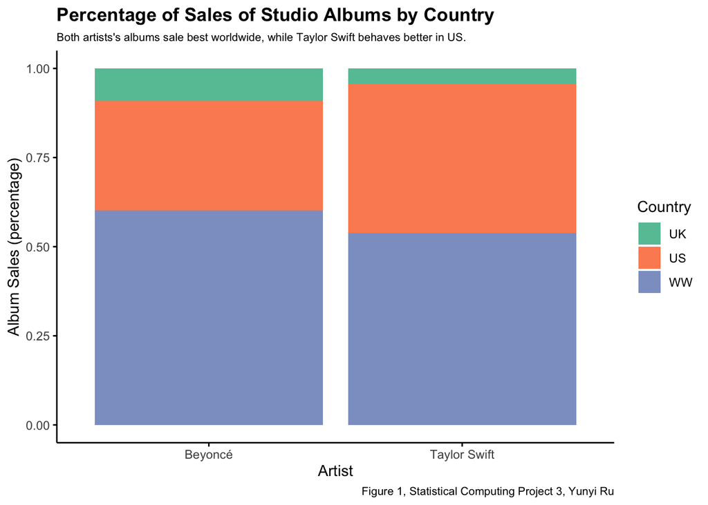

```r
# Step 2
ggplot(p1c, aes(fill = country, y = total_album_sales, x = artist)) +
  geom_bar(position = "fill", stat = "identity") +
  scale_fill_brewer(palette = 'Set2') +
  labs(
    title = 'Percentage of Sales of Studio Albums by Country',
    subtitle = "Both artists's albums sale best worldwide, while Taylor Swift behaves better in US.",
    caption = 'Figure 1, Statistical Computing Project 3, Yunyi Ru',
    y = 'Album Sales (percentage)',
    x = 'Artist',
    fill = 'Country'
  )
```

## Part 1D

Using the wrangled data from Part 1A, use `ggplot2` to create a bar plot for the sales of studio albums (in millions) along the x-axis for each of the album titles along the y-axis.

**Note**:

- You only need to consider the global World sales (you can ignore US and UK sales for this part). Hint: how would you abbreviate *WorldWide*?
- The title of the album must be clearly readable along the y-axis.
- Each bar should be colored by which artist made that album.
- The bars should be ordered from albums with the most sales (top) to the least sales (bottom) (**Note**: you must use functions from `forcats` for this step).

```r
# filter country only == WW
sales.p1d <- sales.p1a %>%
  filter(country == 'WW') %>%
  summarize(sales = sales,
            title = title,
            artist = artist)
```

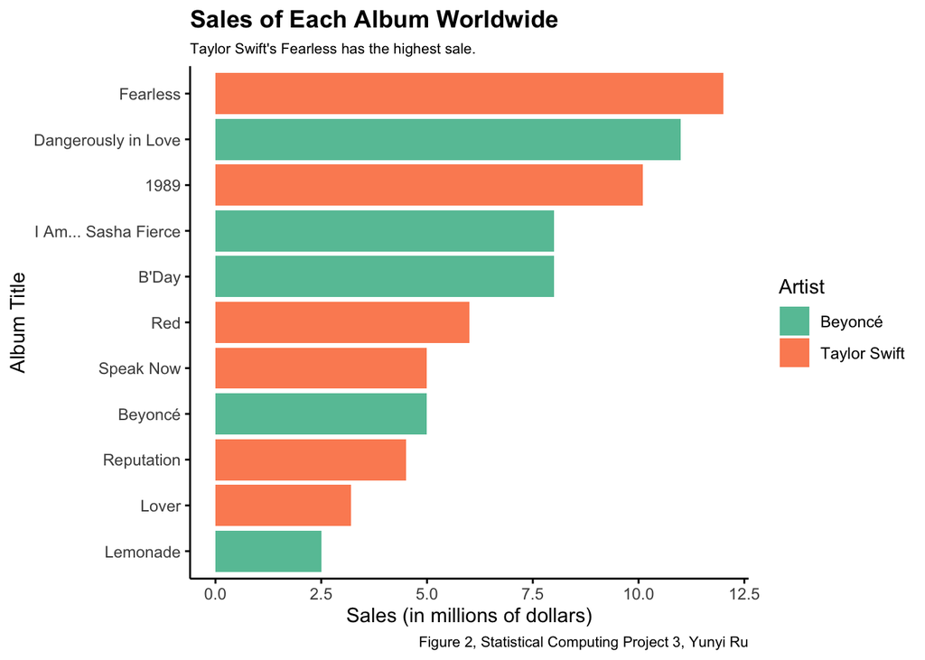

```r
# reorder
sales.p1d <- sales.p1d %>%
  mutate(title = fct_reorder(title, sales, .desc = FALSE))

# make a plot
ggplot(sales.p1d, aes(fill = artist, y = title, x = sales)) +
  geom_col() +
  scale_fill_brewer(palette = 'Set2') +
  labs(
    title = 'Sales of Each Album Worldwide',
    subtitle = "Taylor Swift's Fearless has the highest sale.",
    caption = 'Figure 2, Statistical Computing Project 3, Yunyi Ru',
    y = 'Album Title',
    x = 'Sales (in millions of dollars)',
    fill = 'Artist'
  )
```

## Part 1E

Using the wrangled data from Part 1A, use `ggplot2` to create a scatter plot of sales of studio albums (in millions) along the y-axis by the released date for each album along the x-axis.

**Note**:

- The points should be colored by the artist.
- There should be three scatter plots (one for UK, US and world sales) faceted by rows.

```r
# summarize data
sales.p1e <- sales.p1a %>%
  summarize(
    sales = sales,
    country = country,
    released = released,
    artist = artist,
    title = title
  )
```

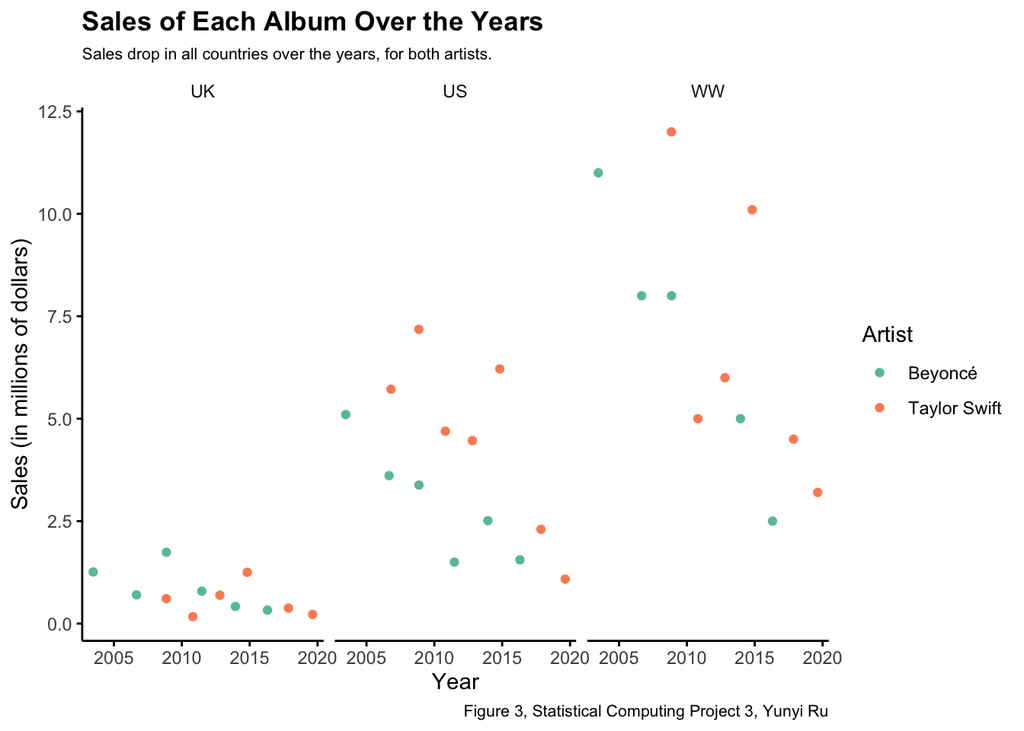

```r
# make a plot
ggplot(sales.p1e, aes(x = released, y = sales, color = artist)) +
  geom_point() +
  facet_wrap( ~ country) +
  scale_color_brewer(palette = 'Set2') +
  labs(
    title = 'Sales of Each Album Over the Years',
    subtitle = "Sales drop in all countries over the years, for both artists.",
    caption = 'Figure 3, Statistical Computing Project 3, Yunyi Ru',
    y = 'Sales (in millions of dollars)',
    x = 'Year',
    color = 'Artist'
  )
```

# Part 2

In Part 2, we will explore the lyrics in the `b_lyrics` and `ts_lyrics` datasets.

# Part 2A

Using `ts_lyrics`, create a new column called `line` with one line containing the character string for each line of Taylor Swift’s songs.

- How many lines in Taylor Swift’s lyrics contain the word “hello”? For full credit, show all the rows in `ts_lyrics` that have “hello” in the `line` column and report how many rows there are in total.
- How many lines in Taylor Swift’s lyrics contain the word “goodbye”? For full credit, show all the rows in `ts_lyrics` that have “goodbye” in the `line` column and report how many rows there are in total.

```r
# make lines
ts_lyrics_lines <- ts_lyrics %>%
  mutate(line = str_split(Lyrics, "\n")) %>%
  unnest(line)

# count 'hello'
p2a_hello <- ts_lyrics_lines %>%
  filter(str_detect(line, '(?i)hello')) %>% # case insensitive
  summarize(Artist = 'Taylor Swift',
            Title = Title,
            Line = line)
# print results
kable(p2a_hello)
```

| Artist | Title | Line |
| --- | --- | --- |
| Taylor Swift | Love Story | And say, “Hello” |
| Taylor Swift | I Almost Do | That I can’t say “Hello” to you |
| Taylor Swift | Everything Has Changed | ’Cause all I know is we said hello |
| Taylor Swift | Everything Has Changed | ’Cause all I know is we said hello |
| Taylor Swift | Everything Has Changed | All I know is we said hello |
| Taylor Swift | Everything Has Changed | All I know is we said hello |

```r
print(paste(
  'There are',
  count(p2a_hello)[1],
  'occurences of Hello in the lyrics of Taylor Swift.'
))
```

```
## [1] "There are 6 occurences of Hello in the lyrics of Taylor Swift."
```

```r
# count 'goodbye'
p2a_goodbye <- ts_lyrics_lines %>%
  filter(str_detect(line, '(?i)goodbye')) %>% # case insensitive
  summarize(Artist = 'Taylor Swift',
            Title = Title,
            Line = line)
# print results
kable(p2a_goodbye)
```

| Artist | Title | Line |
| --- | --- | --- |
| Taylor Swift | Tied Together With A Smile | Goodbye, baby |
| Taylor Swift | Mine | Braced myself for the goodbye, |
| Taylor Swift | Back to December | You gave me all your love and all I gave you was goodbye |
| Taylor Swift | Long Live | And force us into a goodbye |
| Taylor Swift | I Almost Do | And risk another goodbye |
| Taylor Swift | Come Back Be Here | Stumbled through the long goodbye |
| Taylor Swift | All You Had to Do Was Stay | But people like me are gone forever when you say goodbye |
| Taylor Swift | Getaway Car | Said goodbye in |
| Taylor Swift | Getaway Car | Said goodbye in |
| Taylor Swift | Death By A Thousand Cuts | Saying goodbye is death by a thousand cuts |
| Taylor Swift | Death By A Thousand Cuts | ’Cause saying goodbye is death by a thousand cuts |
| Taylor Swift | Daylight | I’ll tell you truth, but never, “Goodbye” |

```r
print(paste(
  'There are',
  count(p2a_goodbye)[1],
  'occurences of Goodbye in the lyrics of Taylor Swift.'
))
```

```
## [1] "There are 12 occurences of Goodbye in the lyrics of Taylor Swift."
```

## Part 2B

Repeat the same analysis for `b_lyrics` as described in Part 2A.

```r
# count 'hello'
p2b_hello <- b_lyrics %>%
  filter(str_detect(line, '(?i)hello')) %>%
  summarize(Artist = 'Beyonce',
            Title = song_name,
            Line = line)
# print results
kable(p2b_hello)
```

| Artist | Title | Line |
| --- | --- | --- |
| Beyonce | Dreamgirls Medley (The Beyonce Experience Live) | Hello world, well I just bought here |
| Beyonce | Fingertips/Master Blaster (Jammin’)/Higher Ground [Live at the “Stevie Wonder Tribute ’Songs In The Key of Life”] (Ft. Ed Sheeran & Gary Clark Jr.) | Hello Stevie, How you feeling |
| Beyonce | FREEDOM (2016 BET Awards) (Ft. Kendrick Lamar) | Fellow great Americans, hello |
| Beyonce | Hello | You had me at hello (Hello) |
| Beyonce | Hello | Hello (Hello) |
| Beyonce | Hello | Hello (Hello) |
| Beyonce | Hello | You had me at hello (Hello) |
| Beyonce | Hello | Hello (Hello) |
| Beyonce | Hello | Hello (Hello) |
| Beyonce | Hello | ’Cause you had me at hello (My cool) (Hello) |
| Beyonce | Hello | Hello (Hello) |
| Beyonce | Hello | Hello (Hello) |
| Beyonce | Hello | You had me at hello (Hello) |
| Beyonce | Hello | Hello (Hello) |
| Beyonce | Hello | Hello (Hello) |
| Beyonce | Hello | You had me at hello (Hello) |
| Beyonce | Hello | Hello (Hello) |
| Beyonce | Hello | Hello (Hello) |
| Beyonce | Hello | You had me at hello (Hello) |
| Beyonce | Hello | Hello (Hello) |
| Beyonce | Hello | Hello (Hello, hello) |
| Beyonce | Hello | You had me at hello (Hello) |
| Beyonce | Hello | Hello (Hello) |
| Beyonce | Hello | Hello (Hello) |
| Beyonce | Hello | You had me at hello (Hello) |
| Beyonce | Hello | Hello (Hello) |
| Beyonce | Hello | Hello (Hello) |
| Beyonce | Hello | You had me at hello (Hello) |
| Beyonce | Hello | Hello (Hello) |
| Beyonce | Hello | Hello (Hello) |

[output cut: 61 more lines]

```r
print(paste(
  'There are',
  count(p2b_hello)[1],
  'occurences of Hello in the lyrics of Beyonce.'
))
```

```
## [1] "There are 91 occurences of Hello in the lyrics of Beyonce."
```

```r
# count 'goodbye'
p2b_goodbye <- b_lyrics %>%
  filter(str_detect(line, '(?i)goodbye')) %>%
  summarize(Artist = 'Beyonce',
            Title = song_name,
            Line = line)
# print results
kable(p2b_goodbye)
```

| Artist | Title | Line |
| --- | --- | --- |
| Beyonce | Back to Black (Ft. André 3000) | We only said goodbye with words |
| Beyonce | Back to Black (Ft. André 3000) | We only said goodbye with words |
| Beyonce | Back to Black (Ft. André 3000) | We only said goodbye with words |
| Beyonce | Best Thing I Never Had | Thank God, I found the good in goodbye |
| Beyonce | Best Thing I Never Had (Lars B Remix) | Thank God, I found the good in goodbye |
| Beyonce | Best Thing I Never Had [Original Version] | Thank God, I found the good in goodbye |
| Beyonce | Gift from Virgo | It’s so hard to say goodbye |
| Beyonce | Gift from Virgo | I never want to say goodbye |
| Beyonce | Gift from Virgo | I never, ever want to say goodbye |
| Beyonce | Hard To Say Goodbye | We’ve got to say goodbye |
| Beyonce | Slow Love | Don’t have to say goodbye |
| Beyonce | Yes | Somewhere between hi and goodbye, I felt so comfortable |

```r
print(paste(
  'There are',
  count(p2b_goodbye)[1],
  'occurences of Goodbye in the lyrics of Beyonce.'
))
```

```
## [1] "There are 12 occurences of Goodbye in the lyrics of Beyonce."
```

## Part 2C

Using the `b_lyrics` dataset,

1. Tokenize each lyrical line by words.
2. Remove the “stopwords”.
3. Calculate the total number for each word in the lyrics.
4. Using the “bing” sentiment lexicon, add a column to the summarized data frame adding the “bing” sentiment lexicon.
5. Sort the rows from most frequent to least frequent words.
6. Only keep the top 25 most frequent words.
7. Auto print the wrangled tibble data frame.
8. Use `ggplot2` to create a bar plot with the top words on the y-axis and the frequency of each word on the x-axis. Color each bar by the sentiment of each word from the “bing” sentiment lexicon. Bars should be ordered from most frequent on the top to least frequent on the bottom of the plot.
9. Create a word cloud of the top 25 most frequent words.

```r
# Step 1: Tokenize
# Create a tibble with 2 columns: line & text
p2c <- b_lyrics %>%
  summarize(Line = 1:22616, Text = line)
# tokenize
p2c_token <- p2c %>%
  unnest_tokens(output = Word,
                input = Text,
                token = 'words')

# Step 2: Drop stopwords
p2c_token_clean <- p2c_token %>%
  anti_join(stop_words, by = c("Word" = "word"))

# Step 3: Calculate the total number of each word in the lyrics
p2c_word_count <- p2c_token_clean %>%
  count(Word, name = 'Word_count', sort = TRUE)

# Step 4 + 5: 'bing' sentiment lexicon + reorder
p2c_word_count <- p2c_word_count %>%
  inner_join(get_sentiments('bing'), by = c("Word" = "word"))

# Step 6: only keep top 25
p2c_word_count_head <- p2c_word_count %>%
  slice(1:25) %>%
  mutate(Word = fct_reorder(Word, Word_count, .desc = FALSE))

# Step 7: print
kable(p2c_word_count_head)
```

| Word | Word_count | sentiment |
| --- | --- | --- |
| love | 1362 | positive |
| crazy | 308 | negative |
| top | 241 | positive |
| bad | 132 | negative |
| beautiful | 131 | positive |
| whoa | 121 | positive |
| damn | 106 | negative |
| hurt | 90 | negative |
| hard | 87 | negative |
| ready | 85 | positive |
| sweet | 84 | positive |
| cool | 76 | positive |
| gold | 75 | positive |
| broken | 72 | negative |
| damned | 72 | negative |
| loving | 72 | positive |
| promise | 69 | positive |
| flawless | 66 | positive |
| slow | 65 | negative |
| lost | 64 | negative |
| shake | 64 | negative |
| mad | 62 | negative |
| shit | 62 | negative |
| freedom | 61 | positive |
| sexy | 61 | positive |

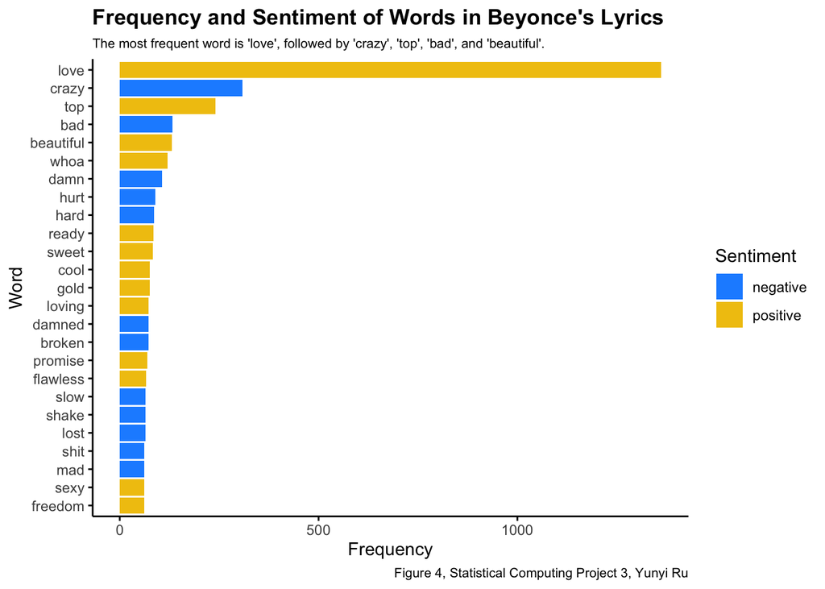

```r
# Step 8: plot
ggplot(p2c_word_count_head, aes(x = Word_count, y = Word, fill = sentiment)) +
  geom_col() +
  scale_fill_manual(values = c('positive' = '#F1C40F', 'negative' = '#1E90FF')) +
  labs(
    title = "Frequency and Sentiment of Words in Beyonce's Lyrics",
    subtitle = "The most frequent word is 'love', followed by 'crazy', 'top', 'bad', and 'beautiful'.",
    caption = 'Figure 4, Statistical Computing Project 3, Yunyi Ru',
    y = 'Word',
    x = 'Frequency',
    fill = 'Sentiment'
  )
```

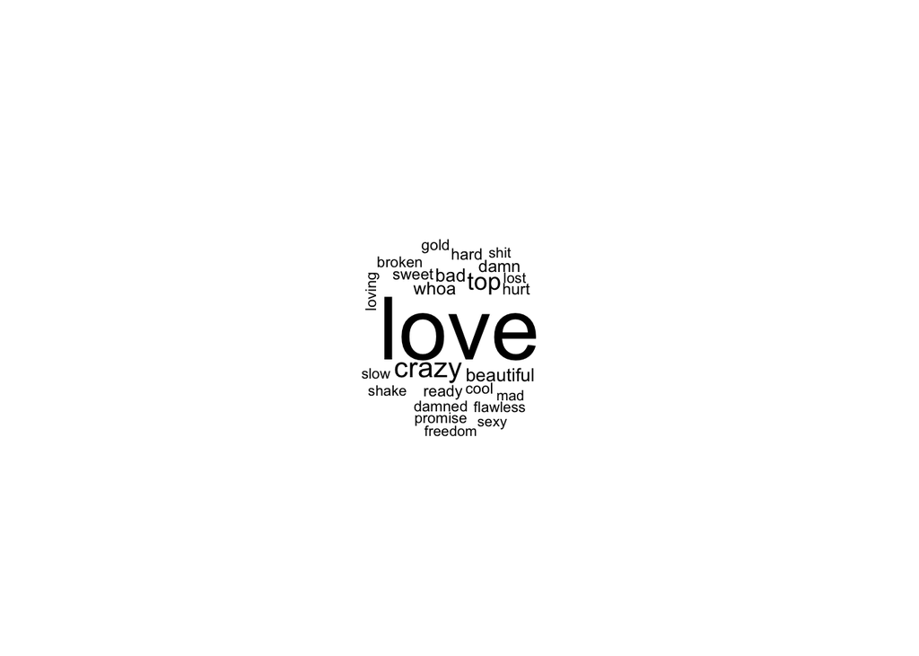

```r
# Step 9: Wordcloud
wordcloud(words = p2c_word_count_head$Word,
          freq = p2c_word_count_head$Word_count,
          random.order = FALSE)
```

## Part 2D

Repeat the same analysis as above in Part 2C, but for `ts_lyrics`.

```r
# Step 1: Tokenize
# Create a tibble with 2 columns: line & text
p2d <- ts_lyrics_lines %>%
  summarize(Line = 1:7168, Text = line)
# tokenize
p2d_token <- p2d %>%
  unnest_tokens(output = Word,
                input = Text,
                token = 'words')

# Step 2: Drop stopwords
p2d_token_clean <- p2d_token %>%
  anti_join(stop_words, by = c("Word" = "word"))

# Step 3: Calculate the total number of each word in the lyrics
p2d_word_count <- p2d_token_clean %>%
  count(Word, name = 'Word_count', sort = TRUE)

# Step 4 + 5: 'bing' sentiment lexicon + reorder
p2d_word_count <- p2d_word_count %>%
  inner_join(get_sentiments('bing'), by = c("Word" = "word"))

# Step 6: only keep top 25
p2d_word_count_head <- p2d_word_count %>%
  slice(1:25) %>%
  mutate(Word = fct_reorder(Word, Word_count, .desc = FALSE))

# Step 7: print
kable(p2d_word_count_head)
```

| Word | Word_count | sentiment |
| --- | --- | --- |
| love | 248 | positive |
| bad | 80 | negative |
| shake | 73 | negative |
| break | 59 | negative |
| mad | 48 | negative |
| beautiful | 46 | positive |
| smile | 45 | positive |
| hate | 44 | negative |
| fall | 43 | negative |
| whoa | 36 | positive |
| lost | 33 | negative |
| nice | 32 | positive |
| trouble | 32 | negative |
| miss | 31 | negative |
| wrong | 31 | negative |
| darling | 30 | positive |
| lose | 28 | negative |
| hard | 27 | negative |
| dark | 26 | negative |
| loved | 25 | positive |
| crazy | 23 | negative |
| fun | 23 | positive |
| cool | 22 | positive |
| shine | 21 | positive |
| fake | 20 | negative |

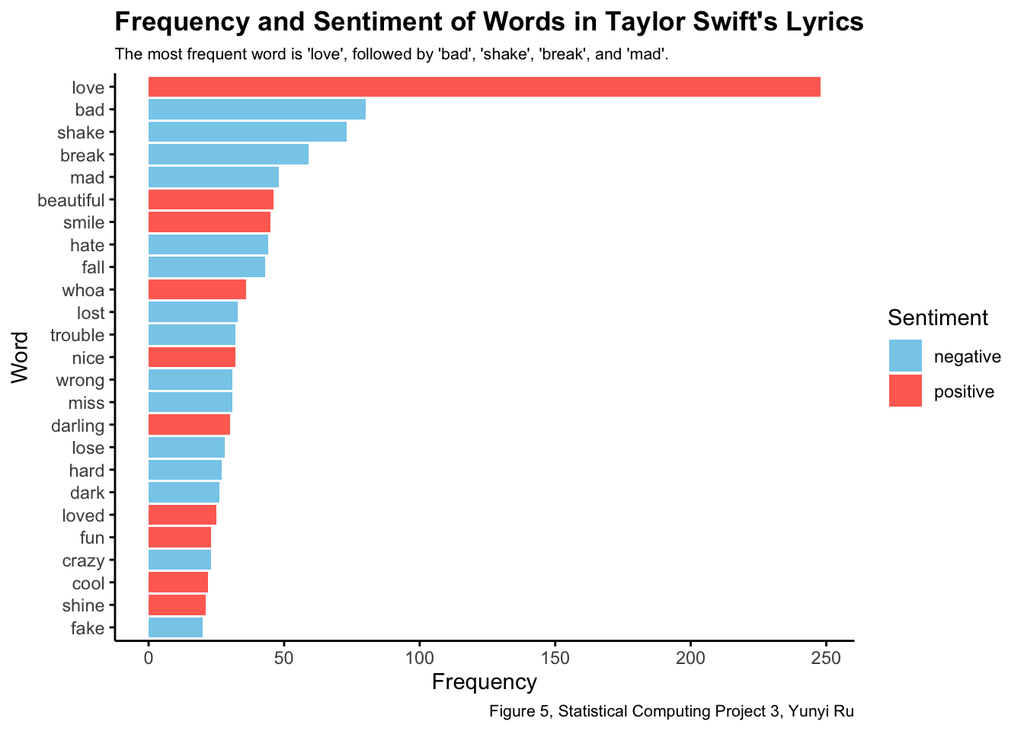

```r
# Step 8: plot
ggplot(p2d_word_count_head, aes(x = Word_count, y = Word, fill = sentiment)) +
  geom_col() +
  scale_fill_manual(values = c('positive' = '#FF6F61', 'negative' = '#87CEEB')) +
  labs(
    title = "Frequency and Sentiment of Words in Taylor Swift's Lyrics",
    subtitle = "The most frequent word is 'love', followed by 'bad', 'shake', 'break', and 'mad'.",
    caption = 'Figure 5, Statistical Computing Project 3, Yunyi Ru',
    y = 'Word',
    x = 'Frequency',
    fill = 'Sentiment'
  )
```

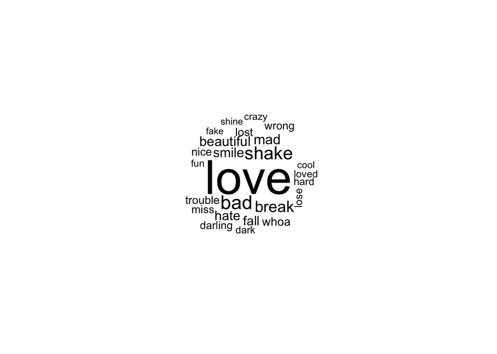

```r
# Step 9: Wordcloud
wordcloud(words = p2d_word_count_head$Word,
          freq = p2d_word_count_head$Word_count,
          random.order = FALSE)
```

## Part 2E

Using the `ts_lyrics` dataset,

1. Tokenize each lyrical line by words.
2. Remove the “stopwords”.
3. Calculate the total number for each word in the lyrics **for each Album**.
4. Using the “afinn” sentiment lexicon, add a column to the summarized data frame adding the “afinn” sentiment lexicon.
5. Calculate the average sentiment score **for each Album**.
6. Auto print the wrangled tibble data frame.
7. Join the wrangled data frame from Part 1A (album sales in millions) filtered down to US sales with the wrangled data frame from #6 above (average sentiment score for each album).
8. Using `ggplot2`, create a scatter plot of the average sentiment score for each album (y-axis) and the album release data along the x-axis. Make the size of each point the album sales in millions.
9. Add a horizontal line at y-intercept=0.
10. Write 2-3 sentences interpreting the plot answering the question “How has the sentiment of Taylor Swift’s albums have changed over time?”. Add a title, subtitle, and useful axis labels.

```r
# Step 1: Tokenize
# Create a tibble with 3 columns: line, album & text
p2e <- ts_lyrics_lines %>%
  summarize(Line = 1:7168,
            Text = line,
            Album = Album)
# tokenize
p2e_token <- p2e %>%
  unnest_tokens(output = Word,
                input = Text,
                token = 'words')

# Step 2: drop stopwords
p2e_token_clean <- p2e_token %>%
  anti_join(stop_words, by = c("Word" = "word"))

# Step 3: group by album, calculate count
p2e_word_count <- p2e_token_clean %>%
  group_by(Album) %>%
  count(Word, name = 'Word_count', sort = TRUE)

# Step 4: Sentiment lexicon 'afinn'
p2e_word_count <- p2e_word_count %>%
  inner_join(get_sentiments('afinn'), by = c("Word" = "word"))

# Step 5: Average Sentiment Score (weighted)
p2e_avg_score <- p2e_word_count %>%
  group_by(Album) %>%
  summarize(weighted_avg = sum(value * Word_count) / sum(Word_count))

# Step 6: Print
kable(p2e_avg_score)
```

| Album | weighted_avg |
| --- | --- |
| 1989 | -0.2149758 |
| Fearless | 0.4517241 |
| Lover | 0.0959821 |
| Red | 0.2563452 |
| Speak Now | 0.0218750 |
| Taylor Swift | 0.6462882 |
| folklore | -0.3956044 |
| reputation | 0.0501393 |

```r
# Step 7: join data
# filter data, country = US, artist = ts
sales.p2e <- sales.p1a %>%
  filter(country == 'US', artist == 'Taylor Swift')

# Check unique values
unique(p2e_avg_score$Album)
```

```
## [1] "1989"         "Fearless"     "Lover"        "Red"          "Speak Now"
## [6] "Taylor Swift" "folklore"     "reputation"
```

```r
unique(sales.p2e$title)
```

```
## [1] "Taylor Swift" "Fearless"     "Speak Now"    "Red"          "1989"
## [6] "Reputation"   "Lover"
```

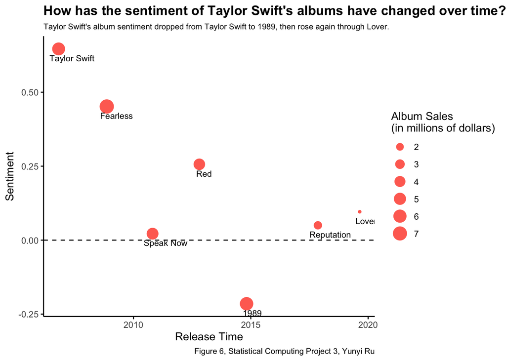

```r
# replace
p2e_avg_score <- p2e_avg_score %>%
  mutate(Album = str_replace(Album, 'reputation', 'Reputation'))

# join
p2e_joined <- left_join(sales.p2e, p2e_avg_score, by = c('title' = 'Album'))

# Step 8/9: plot
ggplot(p2e_joined, aes(x = released, y = weighted_avg)) +
  geom_point(aes(size = sales), color = '#FF6F61') +
  geom_text(aes(label = title), vjust = 2, hjust = 0.2, size = 3) +
  geom_hline(yintercept = 0,
             linetype = 'dashed',
             color = 'black') +
  labs(
    title = "How has the sentiment of Taylor Swift's albums have changed over time?",
    subtitle = "Taylor Swift's album sentiment dropped from Taylor Swift to 1989, then rose again through Lover.",
    caption = 'Figure 6, Statistical Computing Project 3, Yunyi Ru',
    y = 'Sentiment',
    x = 'Release Time',
    size = 'Album Sales\n(in millions of dollars)'
  )
```

# R session information

```r
options(width = 120)
```